# Visualização de dados

Rafael Bassi Stern

March 21, 2018

# Visualização de dados

Além da apresentação de medidas resumo, também é possível resumir a informação nos dados por meio de gráficos. A seguir, discutimos alguns dos principais gráficos usados. Para ilustrar estes gráficos, usaremos o banco de dados *iris* e o banco de dados *adubo*.

```r
library(tidyverse)
data(iris)
adubo = read.csv("./data/adubo.csv")

iris = as.tibble(iris)
adubo = as.tibble(adubo)
adubo$nitrato = as.factor(adubo$nitrato)
adubo$fosfato = as.factor(adubo$fosfato)
```

*Observação*: No **R**, em geral existem muitas opções para gerar o mesmo gráfico. A seguir, mostraremos como gerar gráficos simples usando as funções de base do **R** e, também, gráficos mais elegantes, usando o pacote *ggplot2*. Mais informações sobre este pacote estão disponíveis [aqui](http://material.curso-r.com/ggplot/).

## Strip chart

O **strip chart** é um gráfico para uma variável que é representado em um único eixo e é tal que, cada ponto corresponde ao valor de uma observação. Ainda que para poucas observações este gráfico possa ser informativo, quando há muitas observações ele é de difícil interpretação.

No **R**, o strip chart pode ser obtido pelo comando *stripchart()*. Por exemplo, no banco de dados de adubos, obtemos:

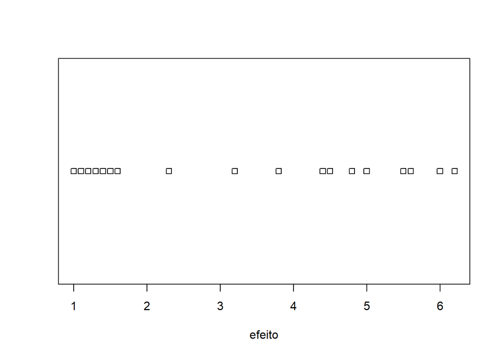

```r
stripchart(adubo$efeito, xlab="efeito")
```

Podemos observar, por exemplo, que das 20 observações, 7 estão concentradas próximo a 1.5. Por outro lado, as outras 13 estão dispersas ao redor de 5. O gráfico levanta uma pergunta: O que nestas 7 observações faz com que o efeito da adubação nelas seja tão menor do que o nas demais observações?

A seguir, note como é difícil interpretar um strip chart produzido com 1000 observações:

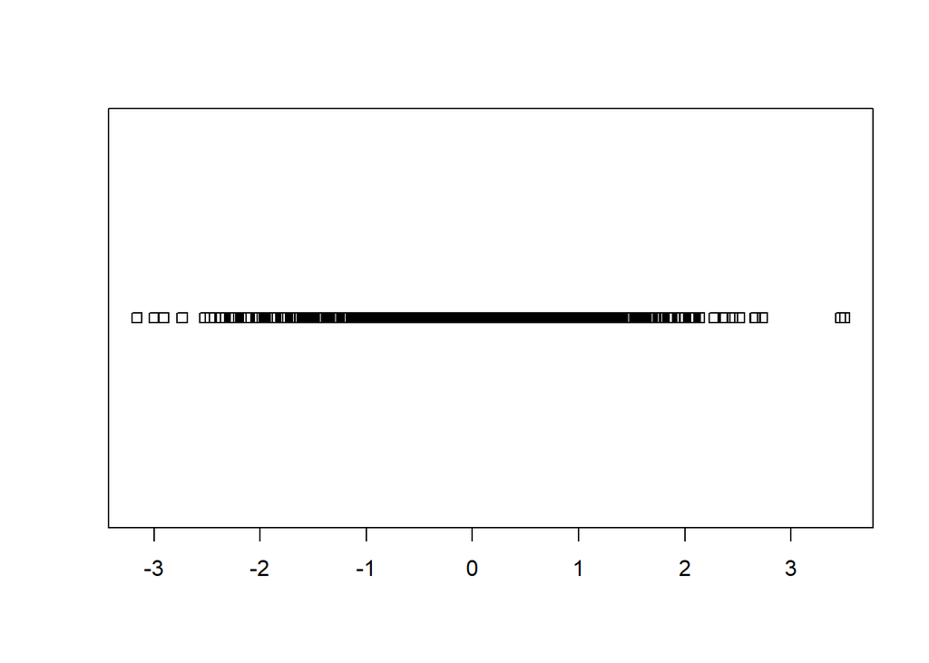

```r
stripchart(rnorm(1000))
```

## Box plot

Um **box plot** (Tukey 1977) é um gráfico para visualizar uma única variável que consiste em apresentar visualmente 5 medidas resumo. Antes de descrever estas medidas, é útil visualizar um boxplot. A seguir, obtemos no **R** um box plot para o comprimento das sépalas no banco de dados *iris*:

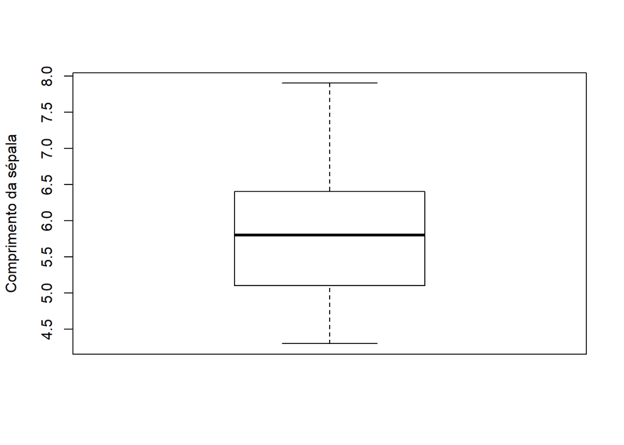

```r
boxplot(iris$Sepal.Length, ylab = "Comprimento da sépala")
```

O box plot contém 5 traços principais. O traço em negrito dentro do retângulo indicam a mediana (Q2) das observações. Os traços nos limites do retângulo indicam o primeiro (Q1) e o terceiro (Q3) quartis. Assim, observamos que cerca de 50% das observações estão dentro do retângulo e que um valor típico para as observações é representado pelo traço em negrito. A seguir, lembre que o intervalo interquartílico (IQR) é definido como $Q3-Q1$. Definimos o limite superior (LS) e inferior (LI) como, respectivamente, $LS=Q3+1.5*IQR$ e $LI=Q1-1.5*IQR$. Os limites das linhas superior e inferior no boxplot são, respectivamente, a maior observação menor que LS e a menor observação maior que LI. Esta é uma faixa de valores tal que seria improvável obter uma observação fora dela. Observações fora destes limites são representadas no boxplot por asteriscos e são comumente chamadas de “outliers”.

Muitas vezes, é útil separar as observações em grupos e construir boxplots para cada um destes. O exemplo a seguir, constrói boxplots para o efeito do adubo quando separamos as observações em 2 grupos: sem ou com nitrato.

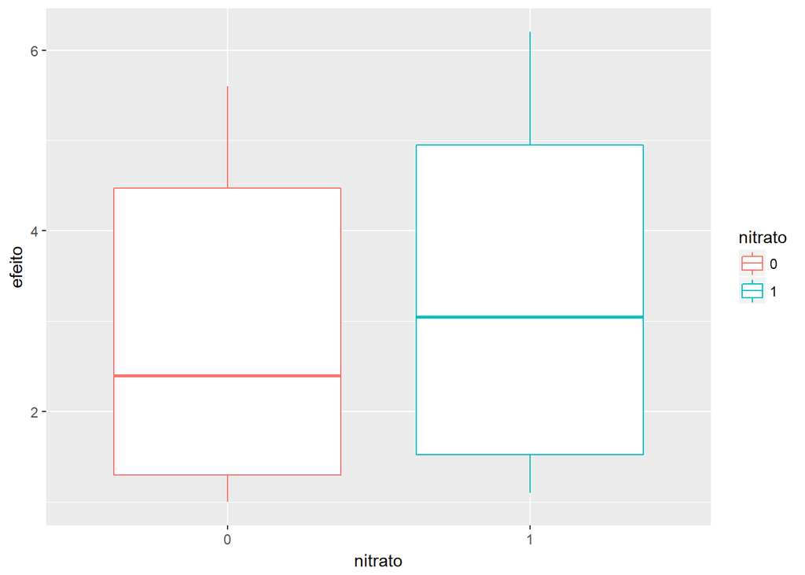

```r
ggplot(aes(y = efeito,
           x = nitrato,
           color = nitrato),
       data = adubo) +
geom_boxplot()
```

Note que, ainda que a mediana no grupo com nitrato seja ligeiramente superior à mediana do grupo sem nitrato, a diferença entre estes valores é insignificante em relação à variabilidade dos dados. Esta conclusão é obtida visualmente vendo que os retângulos vermelho e azul estão praticamente sobrepostos. Este é um cenário em que esperamos que não exista diferença nos efeitos dos dois tipos de adubo.

Por outro lado, podemos separar as observações nos grupos: sem e com fosfato. Neste caso, obtemos as figuras:

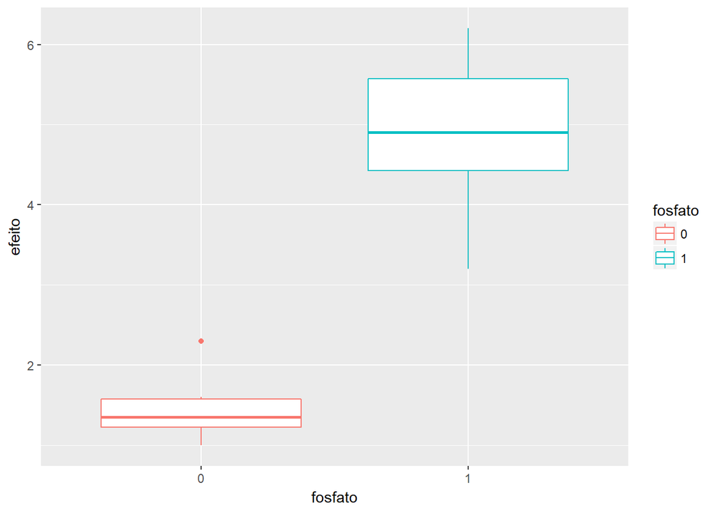

```r
ggplot(aes(y = efeito,
           x = fosfato,
           color = fosfato),
       data = adubo) + geom_boxplot()
```

Neste caso, observe que a diferença entre as medianas de cada grupo é grande em relação à variabilidade dos dados. Por exemplo, verificamos que os boxplots não tem sobreposição. Neste caso, é razoável esperar que os adubos com fosfato tenham um efeito maior do que os adubos sem fosfato.

## Scatter plot

Por vezes, estamos interessados em visualizar a relação entre duas variáveis contínuas. Neste caso, podemos designar um eixo para cada variável e desenhar um ponto para cada observação. Este tipo de gráfico é chamado de **scatter plot**.

No **R** é possível obter o scatter plot usando o comando *plot()*. A seguir, ilustramos este comando no banco de dados *iris* usando como variáveis o comprimento e largura das pétalas.

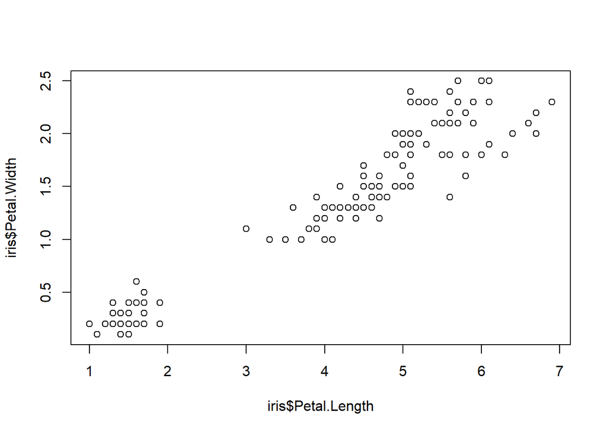

```r
plot(iris$Petal.Length, iris$Petal.Width)
```

Note que, em média, quanto maior o comprimento da pétala, maior será a sua largura. Mais do que isso, parece haver uma relação linear entre estas quantidades. É possível ajustar uma reta que aproxima esta relação linear entre as observações usando o seguinte comando no **R**:

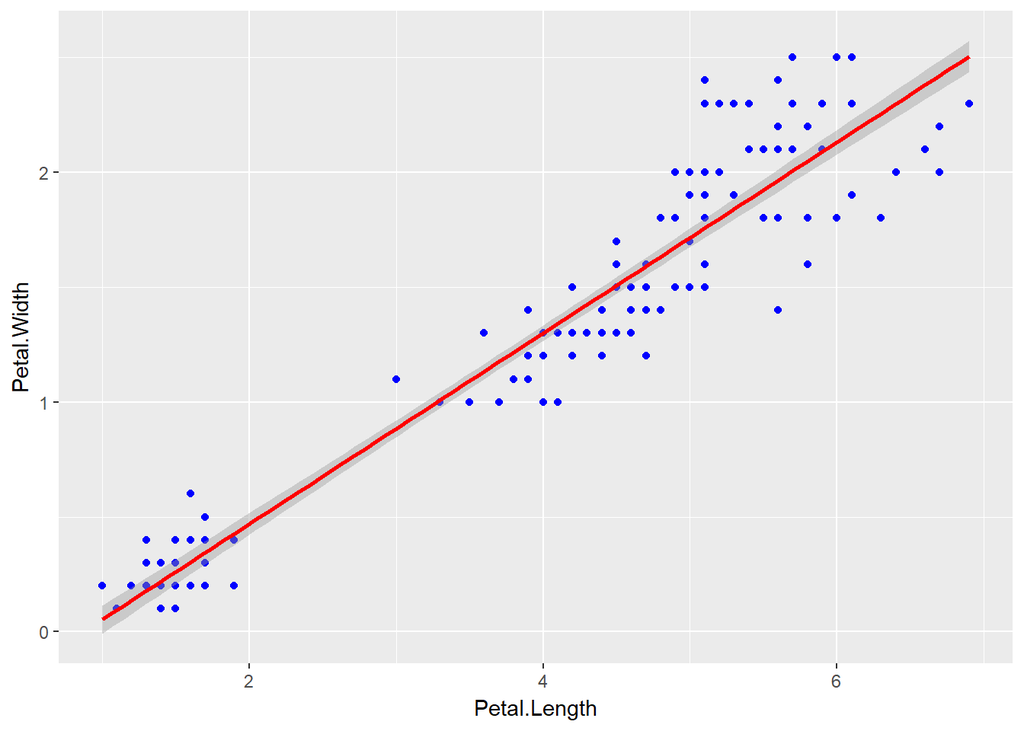

```r
ggplot(aes(x = Petal.Length , y = Petal.Width),
       data = iris) +
geom_point(color='blue') +
geom_smooth(method='lm', color = "red")
```

# Exercícios

1. Construa um boxplot para os dados: 2.3, 2000, 0.1, 1.5, 0.3, 0.7, 0.2, 1.7, 1.2
2. Parece haver uma relação linear entre o comprimento e largura das sépalas no banco de dados *iris*?
3. No banco de dados *iris*, parece haver diferença entre o comprimento das sépalas entre as 3 espécies observadas?

# Referências

Tukey, John W. 1977. *Exploratory Data Analysis*. Addison-Wesley.